# Tipología y ciclo de vida de los datos: Práctica 2

## 1.4 Análisis de los datos

```r
summary(datos)
```

```
##        id             diagnosis          radius_mean      texture_mean
##  Min.   :     8670   Length:568         Min.   : 6.981   Min.   : 9.71
##  1st Qu.:   869222   Class :character   1st Qu.:11.697   1st Qu.:16.18
##  Median :   906157   Mode  :character   Median :13.355   Median :18.86
##  Mean   : 30423820                      Mean   :14.120   Mean   :19.31
##  3rd Qu.:  8825022                      3rd Qu.:15.780   3rd Qu.:21.80
##  Max.   :911320502                      Max.   :28.110   Max.   :39.28
##  perimeter_mean     area_mean      smoothness_mean   compactness_mean
##  Min.   : 43.79   Min.   : 143.5   Min.   :0.05263   Min.   :0.01938
##  1st Qu.: 75.14   1st Qu.: 420.2   1st Qu.:0.08629   1st Qu.:0.06481
##  Median : 86.21   Median : 548.8   Median :0.09587   Median :0.09252
##  Mean   : 91.91   Mean   : 654.3   Mean   :0.09632   Mean   :0.10404
##  3rd Qu.:103.88   3rd Qu.: 782.6   3rd Qu.:0.10530   3rd Qu.:0.13040
##  Max.   :188.50   Max.   :2501.0   Max.   :0.16340   Max.   :0.34540
##  concavity_mean    concave.points_mean symmetry_mean    fractal_dimension_mean
##  Min.   :0.00000   Min.   :0.00000     Min.   :0.1060   Min.   :0.04996
##  1st Qu.:0.02954   1st Qu.:0.02031     1st Qu.:0.1619   1st Qu.:0.05770
##  Median :0.06140   Median :0.03345     Median :0.1792   Median :0.06152
##  Mean   :0.08843   Mean   :0.04875     Mean   :0.1811   Mean   :0.06277
##  3rd Qu.:0.12965   3rd Qu.:0.07373     3rd Qu.:0.1956   3rd Qu.:0.06612
##  Max.   :0.42680   Max.   :0.20120     Max.   :0.3040   Max.   :0.09744
##    radius_se        texture_se      perimeter_se       area_se
##  Min.   :0.1115   Min.   :0.3602   Min.   : 0.757   Min.   :  6.802
##  1st Qu.:0.2324   1st Qu.:0.8331   1st Qu.: 1.605   1st Qu.: 17.850
##  Median :0.3240   Median :1.1095   Median : 2.285   Median : 24.485
##  Mean   :0.4040   Mean   :1.2174   Mean   : 2.856   Mean   : 40.138
##  3rd Qu.:0.4773   3rd Qu.:1.4743   3rd Qu.: 3.337   3rd Qu.: 45.017
##  Max.   :2.8730   Max.   :4.8850   Max.   :21.980   Max.   :542.200
##  smoothness_se      compactness_se      concavity_se     concave.points_se
##  Min.   :0.001713   Min.   :0.002252   Min.   :0.00000   Min.   :0.000000
##  1st Qu.:0.005166   1st Qu.:0.013048   1st Qu.:0.01506   1st Qu.:0.007634
##  Median :0.006374   Median :0.020435   Median :0.02587   Median :0.010920
##  Mean   :0.007042   Mean   :0.025437   Mean   :0.03186   Mean   :0.011789
##  3rd Qu.:0.008151   3rd Qu.:0.032218   3rd Qu.:0.04176   3rd Qu.:0.014710
##  Max.   :0.031130   Max.   :0.135400   Max.   :0.39600   Max.   :0.052790
##   symmetry_se       fractal_dimension_se  radius_worst   texture_worst
##  Min.   :0.007882   Min.   :0.0008948    Min.   : 7.93   Min.   :12.02
##  1st Qu.:0.015128   1st Qu.:0.0022445    1st Qu.:13.01   1st Qu.:21.09
##  Median :0.018725   Median :0.0031615    Median :14.96   Median :25.43
##  Mean   :0.020526   Mean   :0.0037907    Mean   :16.25   Mean   :25.69
##  3rd Qu.:0.023398   3rd Qu.:0.0045258    3rd Qu.:18.77   3rd Qu.:29.76
##  Max.   :0.078950   Max.   :0.0298400    Max.   :36.04   Max.   :49.54
##  perimeter_worst    area_worst     smoothness_worst  compactness_worst
##  Min.   : 50.41   Min.   : 185.2   Min.   :0.07117   Min.   :0.02729
##  1st Qu.: 84.10   1st Qu.: 515.0   1st Qu.:0.11660   1st Qu.:0.14690
##  Median : 97.66   Median : 685.5   Median :0.13130   Median :0.21185
##  Mean   :107.13   Mean   : 878.6   Mean   :0.13232   Mean   :0.25354
##  3rd Qu.:125.17   3rd Qu.:1073.5   3rd Qu.:0.14600   3rd Qu.:0.33760
##  Max.   :251.20   Max.   :4254.0   Max.   :0.22260   Max.   :1.05800
##  concavity_worst  concave.points_worst symmetry_worst   fractal_dimension_worst
##  Min.   :0.0000   Min.   :0.00000      Min.   :0.1565   Min.   :0.05504
##  1st Qu.:0.1145   1st Qu.:0.06473      1st Qu.:0.2504   1st Qu.:0.07141
##  Median :0.2266   Median :0.09984      Median :0.2821   Median :0.08002
##  Mean   :0.2714   Mean   :0.11434      Mean   :0.2898   Mean   :0.08388
##  3rd Qu.:0.3814   3rd Qu.:0.16132      3rd Qu.:0.3177   3rd Qu.:0.09206
##  Max.   :1.2520   Max.   :0.29100      Max.   :0.6638   Max.   :0.20750
```

Podemos observar que la mayoria de datos son númericos continuos, con la excepción de la variable Diagnosis que es tipo categórica y deberemos de factorizar. Tambien podemo ver diferentes scalas o rangos de valores que nos indican que quizas será necesario un proceso de escalado de datos o de normalización. Como vemos la variable categórica unicamente toma dos valores por lo que no necesitamos llevar a cabo un analisis detallado de dicha variable de manera individual.

```r
table(datos$diagnosis)
```

```
##
##   B   M
## 357 211
```

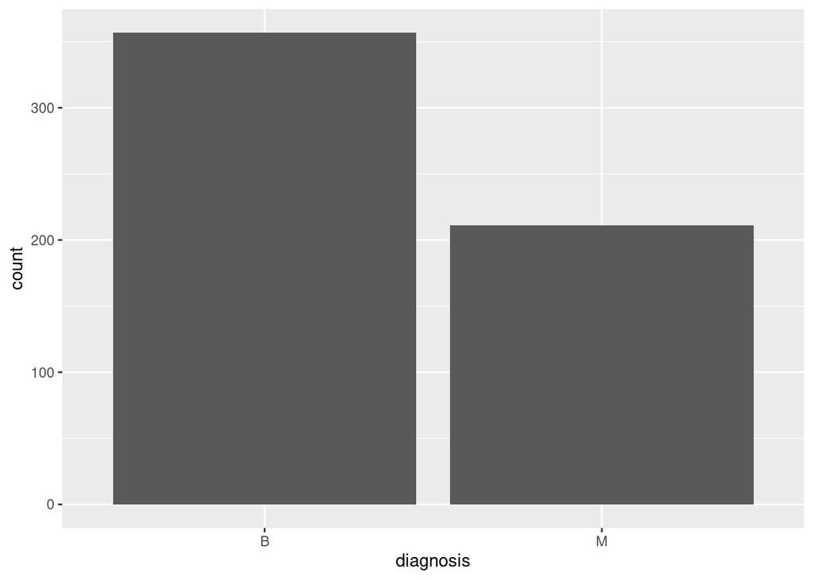

```r
ggplot(data=datos,aes(x=diagnosis))+geom_bar()
```

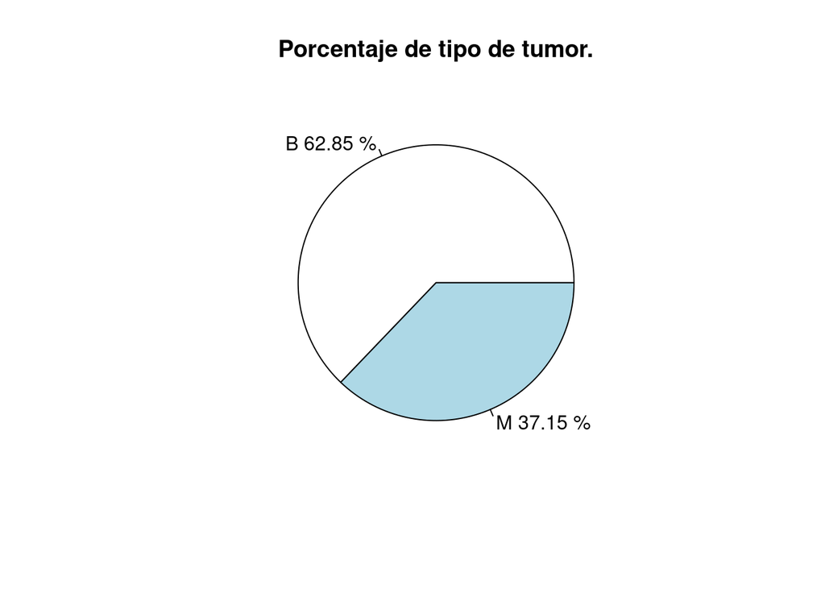

```r
diagnosis.table <- table(datos_limpios$diagnosis)
diagnosis.prop.table <- prop.table(diagnosis.table)*100
lbls <-paste(sort(unique(datos_limpios$diagnosis)),round(diagnosis.prop.table,2), "%")
pie(diagnosis.prop.table, labels = lbls,
   main="Porcentaje de tipo de tumor.")
```

```r
library(gridExtra)
```

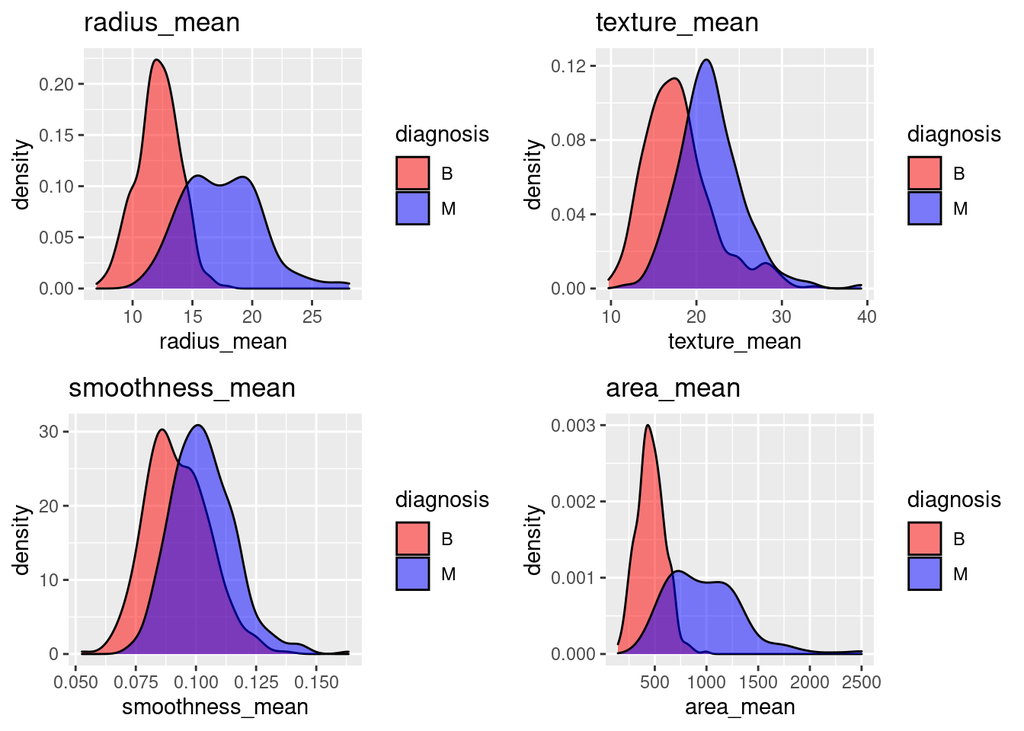

```r
radius_mean <- ggplot(data=datos,aes(x=radius_mean, group=diagnosis, fill=diagnosis))+geom_density(alpha=.5)+
  scale_fill_manual(values=c("red","blue"))+ggtitle("radius_mean")
texture_mean <- ggplot(data=datos,aes(x=texture_mean, group=diagnosis, fill=diagnosis))+geom_density(alpha=.5)+
  scale_fill_manual(values=c("red","blue"))+ggtitle("texture_mean")
smoothness_mean <- ggplot(data=datos,aes(x=smoothness_mean, group=diagnosis, fill=diagnosis))+geom_density(alpha=.5)+
  scale_fill_manual(values=c("red","blue"))+ggtitle("smoothness_mean")
area_mean <- ggplot(data=datos,aes(x=area_mean, group=diagnosis, fill=diagnosis))+geom_density(alpha=.5)+
  scale_fill_manual(values=c("red","blue"))+ggtitle("area_mean")
grid.arrange(radius_mean,texture_mean,smoothness_mean,area_mean,ncol=2)
```

Tras analizar los gráficos de densidad de cada variable, vemos que en las variables area y radio encontramos una diferencia en los valores de estos, aunque ambos comparten un pequeño rango de interesección donde podria ser tanto benigno como maligno.

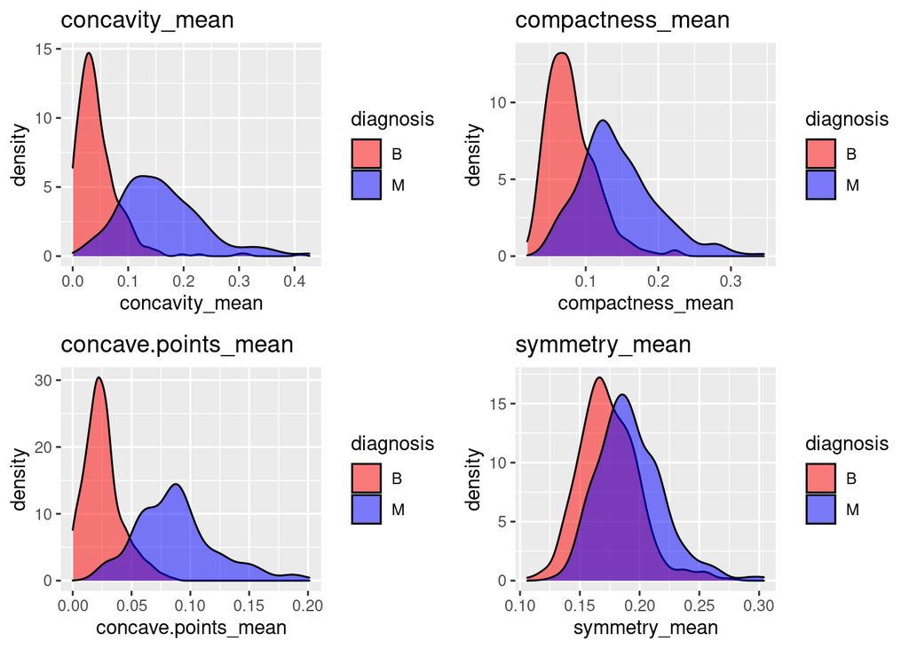

```r
concavity <- ggplot(data=datos,aes(x=concavity_mean, group=diagnosis, fill=diagnosis))+geom_density(alpha=.5)+
  scale_fill_manual(values=c("red","blue"))+ggtitle("concavity_mean")
compactness_mean <- ggplot(data=datos,aes(x=compactness_mean, group=diagnosis, fill=diagnosis))+geom_density(alpha=.5)+
  scale_fill_manual(values=c("red","blue"))+ggtitle("compactness_mean")
concave.points_mean <- ggplot(data=datos,aes(x=concave.points_mean, group=diagnosis, fill=diagnosis))+geom_density(alpha=.5)+
  scale_fill_manual(values=c("red","blue"))+ggtitle("concave.points_mean")
symmetry_mean <- ggplot(data=datos,aes(x=symmetry_mean, group=diagnosis, fill=diagnosis))+geom_density(alpha=.5)+
  scale_fill_manual(values=c("red","blue"))+ggtitle("symmetry_mean")

grid.arrange(concavity,compactness_mean,concave.points_mean,symmetry_mean,ncol=2)
```

Si comprovamos el “worst” de los anteriores atributos:

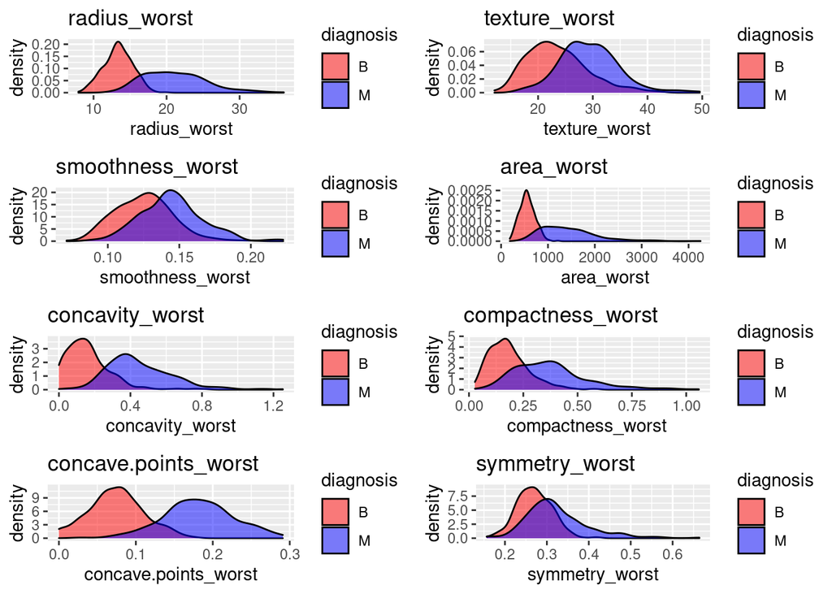

```r
radius_worst <- ggplot(data=datos,aes(x=radius_worst, group=diagnosis, fill=diagnosis))+geom_density(alpha=.5)+
  scale_fill_manual(values=c("red","blue"))+ggtitle("radius_worst")
texture_worst <- ggplot(data=datos,aes(x=texture_worst, group=diagnosis, fill=diagnosis))+geom_density(alpha=.5)+
  scale_fill_manual(values=c("red","blue"))+ggtitle("texture_worst")
smoothness_worst <- ggplot(data=datos,aes(x=smoothness_worst, group=diagnosis, fill=diagnosis))+geom_density(alpha=.5)+
  scale_fill_manual(values=c("red","blue"))+ggtitle("smoothness_worst")
area_worst <- ggplot(data=datos,aes(x=area_worst, group=diagnosis, fill=diagnosis))+geom_density(alpha=.5)+
  scale_fill_manual(values=c("red","blue"))+ggtitle("area_worst")

concavity <- ggplot(data=datos,aes(x=concavity_worst, group=diagnosis, fill=diagnosis))+geom_density(alpha=.5)+
  scale_fill_manual(values=c("red","blue"))+ggtitle("concavity_worst")
compactness_worst <- ggplot(data=datos,aes(x=compactness_worst, group=diagnosis, fill=diagnosis))+geom_density(alpha=.5)+
  scale_fill_manual(values=c("red","blue"))+ggtitle("compactness_worst")
concave.points_worst <- ggplot(data=datos,aes(x=concave.points_worst, group=diagnosis, fill=diagnosis))+geom_density(alpha=.5)+
  scale_fill_manual(values=c("red","blue"))+ggtitle("concave.points_worst")
symmetry_worst <- ggplot(data=datos,aes(x=symmetry_worst, group=diagnosis, fill=diagnosis))+geom_density(alpha=.5)+
  scale_fill_manual(values=c("red","blue"))+ggtitle("symmetry_worst")

grid.arrange(radius_worst,texture_worst,smoothness_worst,area_worst, concavity, compactness_worst, concave.points_worst, symmetry_worst,ncol=2)
```

La mayoria siguen la misma distribución que su media.

Si comparamos las variables _se:

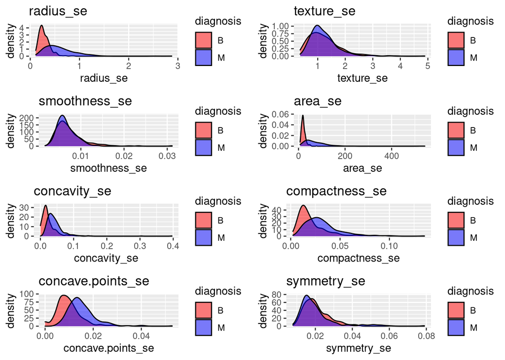

```r
radius_se <- ggplot(data=datos,aes(x=radius_se, group=diagnosis, fill=diagnosis))+geom_density(alpha=.5)+
  scale_fill_manual(values=c("red","blue"))+ggtitle("radius_se")
texture_se <- ggplot(data=datos,aes(x=texture_se, group=diagnosis, fill=diagnosis))+geom_density(alpha=.5)+
  scale_fill_manual(values=c("red","blue"))+ggtitle("texture_se")
smoothness_se <- ggplot(data=datos,aes(x=smoothness_se, group=diagnosis, fill=diagnosis))+geom_density(alpha=.5)+
  scale_fill_manual(values=c("red","blue"))+ggtitle("smoothness_se")
area_se <- ggplot(data=datos,aes(x=area_se, group=diagnosis, fill=diagnosis))+geom_density(alpha=.5)+
  scale_fill_manual(values=c("red","blue"))+ggtitle("area_se")

concavity <- ggplot(data=datos,aes(x=concavity_se, group=diagnosis, fill=diagnosis))+geom_density(alpha=.5)+
  scale_fill_manual(values=c("red","blue"))+ggtitle("concavity_se")
compactness_se <- ggplot(data=datos,aes(x=compactness_se, group=diagnosis, fill=diagnosis))+geom_density(alpha=.5)+
  scale_fill_manual(values=c("red","blue"))+ggtitle("compactness_se")
concave.points_se <- ggplot(data=datos,aes(x=concave.points_se, group=diagnosis, fill=diagnosis))+geom_density(alpha=.5)+
  scale_fill_manual(values=c("red","blue"))+ggtitle("concave.points_se")
symmetry_se <- ggplot(data=datos,aes(x=symmetry_se, group=diagnosis, fill=diagnosis))+geom_density(alpha=.5)+
  scale_fill_manual(values=c("red","blue"))+ggtitle("symmetry_se")

grid.arrange(radius_se,texture_se,smoothness_se,area_se, concavity, compactness_se, concave.points_se, symmetry_se,ncol=2)
```

Hay pequeñas diferencias, pero los benignos como los malignos siguen distribuciones muy muy parecidas en los atributos que ya eran similares en la “media” y en el “worst”.

## 1.5 Comprobación de la normalidad y homogeneidad de la varianza

Para la comprobación de que los valores que toman nuestras variables cuantitativas provienende una población distribuida normalmente, utilizaremos la prueba de normalidad deAnderson-Darling.

H0: La muestra proviene de una distribución normal. H1: La muestra no proviene de una distribución normal. Para pruebas de normalidad siempre se plantean así las hipótesis.

```r
if (!require('nortest')) install.packages('nortest');library('nortest')
alpha = 0.05
col.names =colnames(datos)

for (i in 1:ncol(datos)) {
  if (i == 1) cat("Variables que no siguen una distribución normal:\n")
  if (is.integer(datos[,i]) |is.numeric(datos[,i])) {
    p_val =ad.test(datos[,i])$p.value
    if (p_val < alpha) {
      cat(col.names[i])

      if (i <ncol(datos) - 1)cat(", ")
      if (i %% 3 == 0)cat("\n")
    }
  }
}
```

```
## Variables que no siguen una distribución normal:
## id, radius_mean,
## texture_mean, perimeter_mean, area_mean,
## smoothness_mean, compactness_mean, concavity_mean,
## concave.points_mean, symmetry_mean, fractal_dimension_mean,
## radius_se, texture_se, perimeter_se,
## area_se, smoothness_se, compactness_se,
## concavity_se, concave.points_se, symmetry_se,
## fractal_dimension_se, radius_worst, texture_worst,
## perimeter_worst, area_worst, smoothness_worst,
## compactness_worst, concavity_worst, concave.points_worst,
## symmetry_worstfractal_dimension_worst
```

Las variables no siguen una distribucion normal ya que: Si P < Alfa Se rechaza Ho Si p >= Alfa No se rechaza Ho

Para estudiar la homogeneidad de varianzas, hemos decidido utilizar el test de Fligner-Killeen:

En este caso solo he probado la homogeniedad de la variable radius_mean en comparacion con la variable decisiva “diagnosis”.

```r
fligner.test(radius_mean ~ diagnosis, data = datos)
```

```
##
##  Fligner-Killeen test of homogeneity of variances
##
## data:  radius_mean by diagnosis
## Fligner-Killeen:med chi-squared = 80.523, df = 1, p-value < 2.2e-16
```

Como el p-value es inferior a 0.05, descartamos que las variables son homogenias.

## 1.6 Correlacion de las variables

Una vez hemos visto como se distribuyen los datos en la variable categórica para ver los porcentajes, vamos a ver la correlación de nuestras variables, aquellas muy correlacionadas son de menor interés.

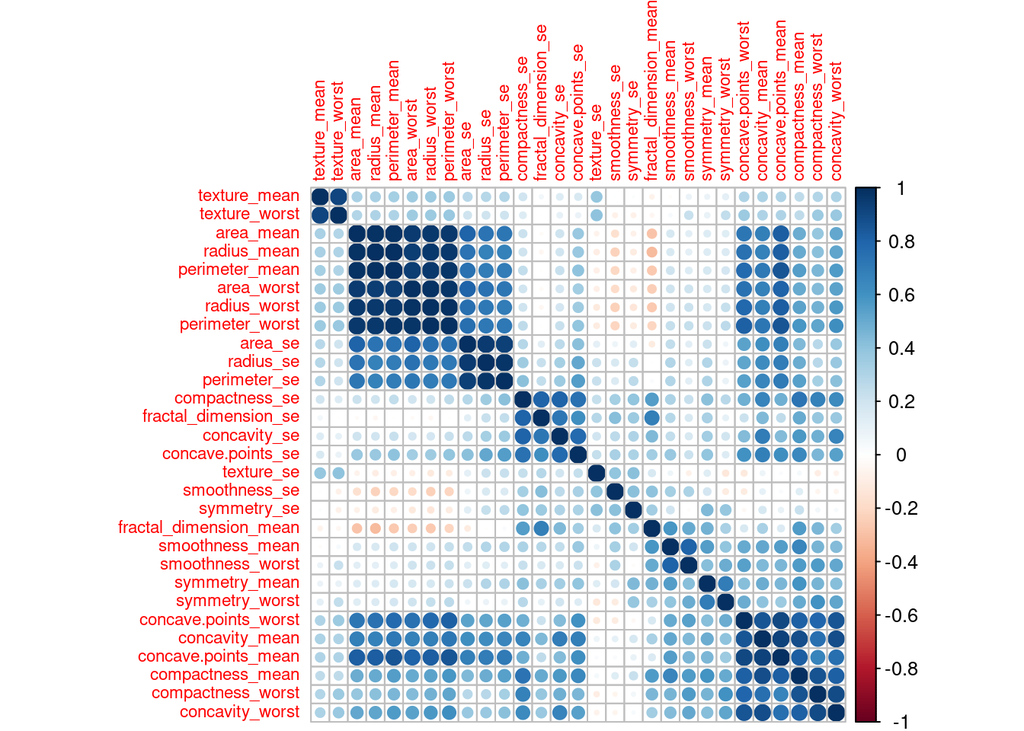

```r
library("corrplot")
c <- cor(datos_limpios[,3:31])
corrplot(c, order = "hclust", tl.cex = 0.7)
```

Como todas las variables seleccionadas son variables númericas podemos ver con la tabla de correlación la correlación directa entre dichas variables. A simple vista podemos ver que ciertas variables tienen una mayor correlación con otras, como tenemos un grán número de variables y hemos llevado a cabo de antemano PCA y hemos obtenido las variables que más contribuyen a la explicación de los datos, cogeremos dichas variables para continuar con el estudio del problema.

## 1.7 Qué variables cuantitativas influyen más en el cancer?

Si aplicamos un PCA, podemos identificar las variables con mas peso en el dataset: Mediante PCA obtendremos las componentes principales, estas componentes principales nos indican la dirección en dond hay una mayor varianza por lo tanto una menor correlación. Para poder ver cuanta varianza hay en una dirección nos podemos ayudar de los autovaloes y autovectores de la matriz de covarianza.

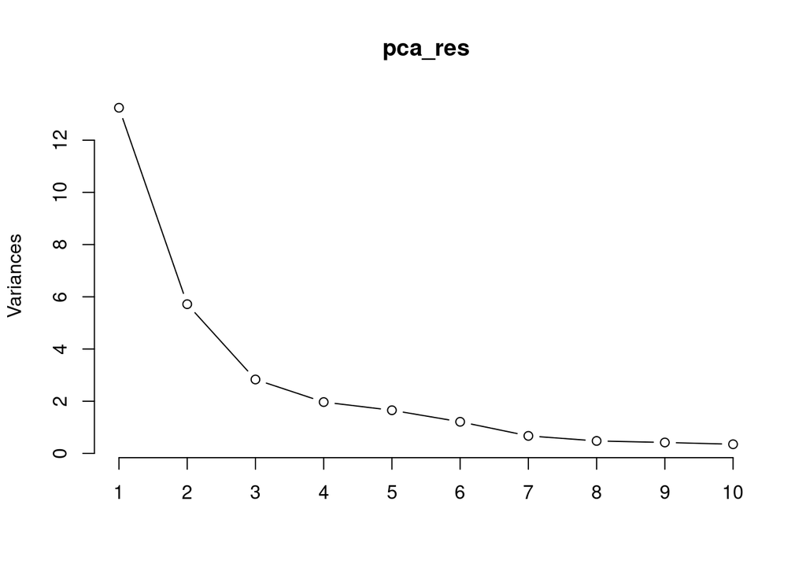

```r
datos_numericos <- datos
datos_numericos$diagnosis <- NULL
pca_res <- prcomp(datos_numericos[,2:ncol(datos_numericos)], center = TRUE, scale = TRUE)
plot(pca_res, type="l")
```

Podemos ver con la gráfica que al parecer las 6 primeras componentes principales explican de manera clara nuestro conjunto de daos, vamos a verlo de manera numérica.

```r
summary(pca_res)
```

```
## Importance of components:
##                           PC1    PC2     PC3     PC4     PC5     PC6     PC7
## Standard deviation     3.6390 2.3910 1.68292 1.40254 1.28592 1.10053 0.81945
## Proportion of Variance 0.4414 0.1906 0.09441 0.06557 0.05512 0.04037 0.02238
## Cumulative Proportion  0.4414 0.6320 0.72638 0.79195 0.84707 0.88744 0.90982
##                            PC8     PC9    PC10    PC11    PC12   PC13    PC14
## Standard deviation     0.69137 0.64732 0.59273 0.54361 0.51103 0.4929 0.39627
## Proportion of Variance 0.01593 0.01397 0.01171 0.00985 0.00871 0.0081 0.00523
## Cumulative Proportion  0.92576 0.93972 0.95143 0.96129 0.96999 0.9781 0.98332
##                           PC15    PC16    PC17    PC18    PC19    PC20    PC21
## Standard deviation     0.30692 0.28179 0.24431 0.22876 0.22335 0.17668 0.17366
## Proportion of Variance 0.00314 0.00265 0.00199 0.00174 0.00166 0.00104 0.00101
## Cumulative Proportion  0.98646 0.98911 0.99110 0.99284 0.99451 0.99555 0.99655
##                           PC22    PC23    PC24    PC25    PC26    PC27  PC28
## Standard deviation     0.16625 0.15653 0.13482 0.12493 0.09048 0.08258 4e-02
## Proportion of Variance 0.00092 0.00082 0.00061 0.00052 0.00027 0.00023 5e-05
## Cumulative Proportion  0.99747 0.99829 0.99890 0.99942 0.99969 0.99992 1e+00
##                           PC29    PC30
## Standard deviation     0.02736 0.01135
## Proportion of Variance 0.00002 0.00000
## Cumulative Proportion  1.00000 1.00000
```

Como se parecia ver, con las 6 primeras variables explicamos casi el 89% de la variación de los datos.

Vamos obtener los autovectores y autovalores de nuestro dataset. Es importante que el número de autovectores y autovalores que tenga nuestro dataset será el número de dimensiones que tendrás. Como es de esperar tendremos el mismo número que variables, pero el valor del autovalor y en que dirección marcan que es variable sea considera como componente principal.

```r
e <- eigen(cor(datos_numericos[,2:ncol(datos_numericos)]))
print(round(e$values, 4))
```

```
##  [1] 13.2422  5.7169  2.8322  1.9671  1.6536  1.2112  0.6715  0.4780  0.4190
## [10]  0.3513  0.2955  0.2612  0.2430  0.1570  0.0942  0.0794  0.0597  0.0523
## [19]  0.0499  0.0312  0.0302  0.0276  0.0245  0.0182  0.0156  0.0082  0.0068
## [28]  0.0016  0.0007  0.0001
```

Podemos ver que tenemos 5-6 autovalores con bastante peso, esto indica que nuestro dataset se ve orientado por esas 5-6 variables, vemos por lo tanto que tenemos como PCA indicaba que 6 serian las componenet principales que más identifican los datos. El peso de la 7 PCA es muy insignificante en comparación al resto.

Una vez vemos que tenemos 6 componentes principales tenemos que ver que variables son las que tienen un mayor peso en cada una.

```r
library(factoextra)
```

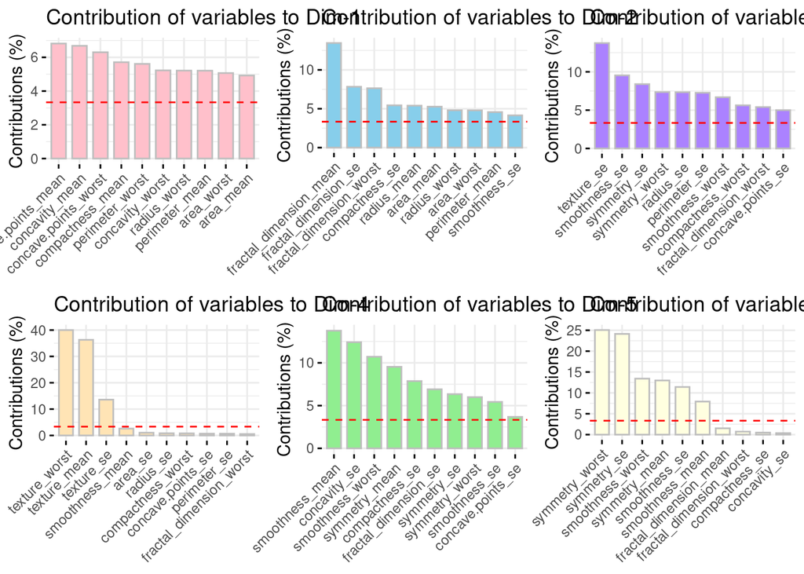

```r
library(gridExtra)
p1 <- fviz_contrib(pca_res, choice="var", axes=1, fill="pink", color="grey", top=10)
p2 <- fviz_contrib(pca_res, choice="var", axes=2, fill="skyblue", color="grey", top=10)
p3 <- fviz_contrib(pca_res, choice="var", axes=3, fill="mediumpurple1", color="grey", top=10)
p4 <- fviz_contrib(pca_res, choice="var", axes=4, fill="moccasin", color="grey", top=10)
p5 <- fviz_contrib(pca_res, choice="var", axes=5, fill="lightgreen", color="grey", top=10)
p6 <- fviz_contrib(pca_res, choice="var", axes=6, fill="lightyellow1", color="grey", top=10)
grid.arrange(p1,p2,p3,p4,p5,p6,ncol=3)
```

Como buscamos predecir nuevas canceres y clasificarlos, emplearemos una técnica conocida para la selección de variables, esta técnia se basa en random forest y la importancia sobre la variable que queremos trabajar.

```r
library('FSelector')
attribute.scores <- random.forest.importance(diagnosis ~ ., datos)
attribute.scores
```

```
##                         attr_importance
## id                             6.459930
## radius_mean                   14.002185
## texture_mean                  18.725421
## perimeter_mean                12.467163
## area_mean                     14.634583
## smoothness_mean               10.286407
## compactness_mean               8.716143
## concavity_mean                16.235735
## concave.points_mean           21.652469
## symmetry_mean                  6.236720
## fractal_dimension_mean         6.009734
## radius_se                     14.602400
## texture_se                     5.791047
## perimeter_se                  14.475934
## area_se                       18.126376
## smoothness_se                  4.822129
## compactness_se                 7.376927
## concavity_se                   8.622700
## concave.points_se              7.004115
## symmetry_se                    2.701824
## fractal_dimension_se           5.610760
## radius_worst                  25.956442
## texture_worst                 19.999178
## perimeter_worst               24.072820
## area_worst                    26.055215
## smoothness_worst              16.358672
## compactness_worst             11.066831
## concavity_worst               18.700842
## concave.points_worst          26.331975
## symmetry_worst                10.766120
## fractal_dimension_worst        6.567109
```

```r
Top_6_features<-cutoff.k(attribute.scores, k = 6)
Top_6_features
```

```
## [1] "concave.points_worst" "area_worst"           "radius_worst"
## [4] "perimeter_worst"      "concave.points_mean"  "texture_worst"
```

Podemos ver que algunas si son las variables que nos indicaban cada uno de los componentes principales, pero otras no. La selección de las variables para el analisis dependerá en gran medida del conocimiento del radiólogo o doctor que nos ayude en la elaboración de los modelos. Por el momento y tras comprobar que todas las variables que mostramos tienen un peso importante en las PCA las tomamos para el análisis.

## 1.8 Predicción de cancer

```r
set.seed(150)
cancer_entrenamiento <- sample_frac(datos, .7)
cancer_test <- setdiff(datos, cancer_entrenamiento)
```

Tras dividir los datos procedemos a crear nuestro modelo, en este caso se trata del modelo de clasificación CART.

```r
if(!require(rpart)){
    install.packages(rpart)
    library(rpart)
}
model_dtree<- rpart(cancer_entrenamiento$diagnosis~., data=cancer_entrenamiento,
                    method = "class",
                    parms = list(split ="information"),
                    control = rpart.control(cp= 0.00001))
```

A continuación procedemos a ver las reglas creades

```r
library(rpart.plot)
rpart.rules(model_dtree,style = 'tall',cover = T)
```

```
## cancer_entrenamiento$diagnosis is 0.00 with cover 2% when
##     radius_worst < 17
##     concave.points_worst >= 0.14
##     texture_worst < 27
##     area_se < 21
##
## cancer_entrenamiento$diagnosis is 0.02 with cover 61% when
##     radius_worst < 17
##     concave.points_worst < 0.14
##
## cancer_entrenamiento$diagnosis is 0.58 with cover 3% when
##     radius_worst < 17
##     concave.points_worst >= 0.14
##     texture_worst < 27
##     area_se >= 21
##
## cancer_entrenamiento$diagnosis is 0.95 with cover 31% when
##     radius_worst >= 17
##
## cancer_entrenamiento$diagnosis is 1.00 with cover 3% when
##     radius_worst < 17
##     concave.points_worst >= 0.14
##     texture_worst >= 27
```

Ahora mediante summary podemos observar las variables principales con mayor peso en la toma de decesiones para clasificar.

```r
summary(model_dtree)
```

```
## Call:
## rpart(formula = cancer_entrenamiento$diagnosis ~ ., data = cancer_entrenamiento,
##     method = "class", parms = list(split = "information"), control = rpart.control(cp = 1e-05))
##   n= 398
##
##           CP nsplit rel error    xerror       xstd
## 1 0.79285714      0 1.0000000 1.0000000 0.06804627
## 2 0.03928571      1 0.2071429 0.2857143 0.04284518
## 3 0.01428571      3 0.1285714 0.2071429 0.03703758
## 4 0.00001000      4 0.1142857 0.1928571 0.03583433
##
## Variable importance
##           area_worst         radius_worst      perimeter_worst
##                   16                   16                   15
##            area_mean       perimeter_mean          radius_mean
##                   14                   14                   14
## concave.points_worst      concavity_worst     compactness_mean
##                    3                    1                    1
##  concave.points_mean    compactness_worst       concavity_mean
##                    1                    1                    1
##        texture_worst         texture_mean
##                    1                    1
##
## Node number 1: 398 observations,    complexity param=0.7928571
##   predicted class=B  expected loss=0.3517588  P(node) =1
##     class counts:   258   140
##    probabilities: 0.648 0.352
##   left son=2 (275 obs) right son=3 (123 obs)
##   Primary splits:
##       radius_worst         < 16.795   to the left,  improve=155.0611, (0 missing)
##       perimeter_worst      < 116.25   to the left,  improve=151.8464, (0 missing)
##       area_worst           < 874.85   to the left,  improve=150.2767, (0 missing)
##       concave.points_worst < 0.14545  to the left,  improve=150.2767, (0 missing)
##       concave.points_mean  < 0.05142  to the left,  improve=147.6779, (0 missing)
##   Surrogate splits:
##       area_worst      < 868.2    to the left,  agree=0.995, adj=0.984, (0 split)
##       perimeter_worst < 111.7    to the left,  agree=0.980, adj=0.935, (0 split)
##       radius_mean     < 15.02    to the left,  agree=0.960, adj=0.870, (0 split)
##       perimeter_mean  < 96.405   to the left,  agree=0.960, adj=0.870, (0 split)
##       area_mean       < 700.35   to the left,  agree=0.960, adj=0.870, (0 split)
```

[output cut: 64 more lines]

```
##
## Node number 11: 11 observations
##   predicted class=M  expected loss=0  P(node) =0.02763819
##     class counts:     0    11
##    probabilities: 0.000 1.000
##
## Node number 20: 8 observations
##   predicted class=B  expected loss=0  P(node) =0.0201005
##     class counts:     8     0
##    probabilities: 1.000 0.000
##
## Node number 21: 12 observations
##   predicted class=M  expected loss=0.4166667  P(node) =0.03015075
##     class counts:     5     7
##    probabilities: 0.417 0.583
```

Tras un pequeño análisis de los resultados del modelo, clasificamos los valores del test.

```r
prediccion_1 <- predict(model_dtree,cancer_test, type = "class")
library(caret)
(conf_matrix_dtree <- table(prediccion_1,cancer_test$diagnosis))
```

```
##
## prediccion_1  B  M
##            B 91  1
##            M  8 70
```

```r
confusionMatrix(conf_matrix_dtree)
```

```
## Confusion Matrix and Statistics
##
##
## prediccion_1  B  M
##            B 91  1
##            M  8 70
##
##                Accuracy : 0.9471
##                  95% CI : (0.9019, 0.9755)
##     No Information Rate : 0.5824
##     P-Value [Acc > NIR] : <2e-16
##
##                   Kappa : 0.8927
##
##  Mcnemar's Test P-Value : 0.0455
##
##             Sensitivity : 0.9192
##             Specificity : 0.9859
##          Pos Pred Value : 0.9891
##          Neg Pred Value : 0.8974
##              Prevalence : 0.5824
##          Detection Rate : 0.5353
##    Detection Prevalence : 0.5412
##       Balanced Accuracy : 0.9526
##
##        'Positive' Class : B
##
```

```r
print(model_dtree)
```

```
## n= 398
##
## node), split, n, loss, yval, (yprob)
##       * denotes terminal node
##
##  1) root 398 140 B (0.64824121 0.35175879)
##    2) radius_worst< 16.795 275  23 B (0.91636364 0.08363636)
##      4) concave.points_worst< 0.1358 244   5 B (0.97950820 0.02049180) *
##      5) concave.points_worst>=0.1358 31  13 M (0.41935484 0.58064516)
##       10) texture_worst< 27.385 20   7 B (0.65000000 0.35000000)
##         20) area_se< 21.025 8   0 B (1.00000000 0.00000000) *
##         21) area_se>=21.025 12   5 M (0.41666667 0.58333333) *
##       11) texture_worst>=27.385 11   0 M (0.00000000 1.00000000) *
##    3) radius_worst>=16.795 123   6 M (0.04878049 0.95121951) *
```

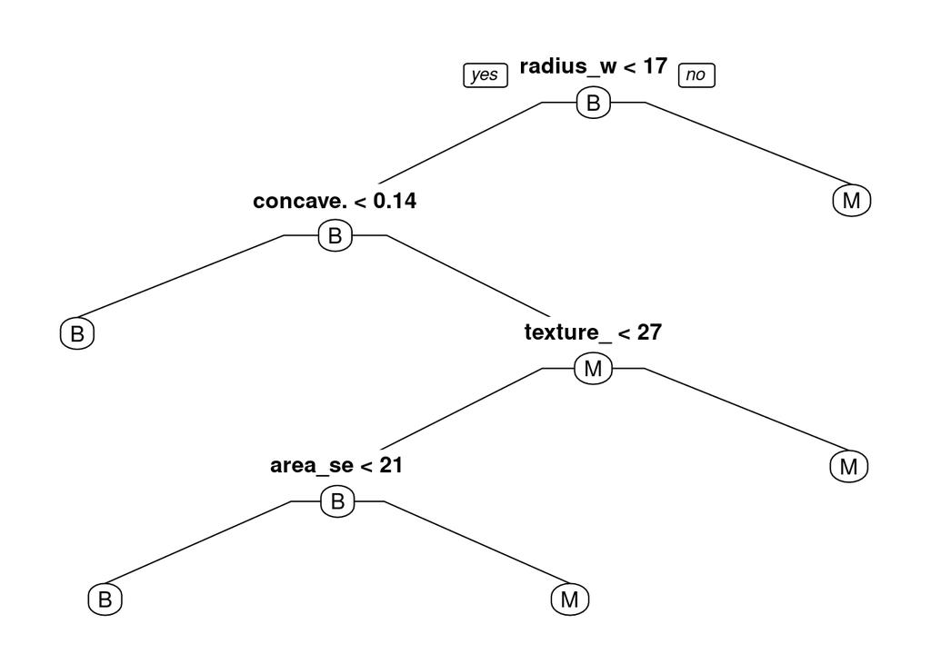

```r
prp(model_dtree,type=1)
```

Vamos a ver si optimizando nuestro modelo obtenemos un acierto mayor.

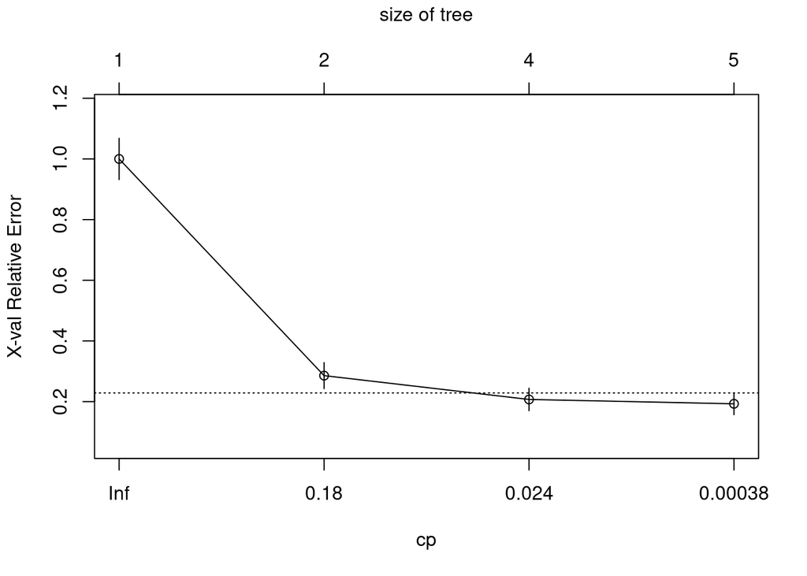

```r
plotcp(model_dtree)
```

```r
model_dtree_2<- rpart(cancer_entrenamiento$diagnosis~., data=cancer_entrenamiento,
                    method = "class",
                    parms = list(split ="information"),
                    control = rpart.control(cp= 0.017))
prediccion_2 <- predict(model_dtree,cancer_test, type = "class")
(conf_matrix_dtree <- table(prediccion_2,cancer_test$diagnosis))
```

```
##
## prediccion_2  B  M
##            B 91  1
##            M  8 70
```

```r
confusionMatrix(conf_matrix_dtree)
```

```
## Confusion Matrix and Statistics
##
##
## prediccion_2  B  M
##            B 91  1
##            M  8 70
##
##                Accuracy : 0.9471
##                  95% CI : (0.9019, 0.9755)
##     No Information Rate : 0.5824
##     P-Value [Acc > NIR] : <2e-16
##
##                   Kappa : 0.8927
##
##  Mcnemar's Test P-Value : 0.0455
##
##             Sensitivity : 0.9192
##             Specificity : 0.9859
##          Pos Pred Value : 0.9891
##          Neg Pred Value : 0.8974
##              Prevalence : 0.5824
##          Detection Rate : 0.5353
##    Detection Prevalence : 0.5412
##       Balanced Accuracy : 0.9526
##
##        'Positive' Class : B
##
```

Otra opción sería emplear otro método de clasificación como puede ser C50 o random forest.

## 1.9 Conclusión

En este proyecto hemos abordado todos los aspectos que implican un trabajo de mineria de datos. Desde la selección y explicación de los datos, hasta llevar a cabo procesos de limpieza,analisis de correlación y de homogeneidad, así como la implementación de técnicas de clasificación.

Pretende ser una guía básica de los pasos que son necesarios implementar en todo proyecto de minería de datos.

En concreto con los datos tratados, hemos podido observar cuales son las variables con mayor peso en la predicción del cancer, como pueden ser el radius worts y el texture worst entre otras. Tras ello hemos aplicado un metodo de clasificación el cula no podrá servir para predecir futuros canceres. Así como hemos podido obtener una série de reglas que se podrian implementar en los reconocimientos de pacientes en los diferentes hospitales.